# Association between miRNA activity and miRNA abundance across TCGA tumors

# 7 miRNA activity vs expression correlations

For each cancer and each pair of mature miRNA and miRNA family, correlate mature miRNA abundance and miRNA (family) activity. Output plots showing the probability density functions of Pearson correlations between inferred activity and abundance pairs of mature miRNAs and miRNA family that are matching, or not, in all TCGA cancers for which activity was inferred. miRNAs with significant changes in activity in at least 10 tumor samples in at least one cancer type are included.

```r
# Get all the miRNAs (MiRBase IDs) included in the miRNA families of interest
miROIs <- unique(gsub("\\.1$", "",
  fams[fams$`miR family` %in% miRNAs_TS_fam, ]$`MiRBase ID`))

# Process each cancer type
results <- lapply(cancers, function(cancer) {
  # Load abundance data, filter for tumors
  miR_expr_T <- load_mir_abundance(cancer)

  # Extract activity from glm_results, filter for tumors
  miR_act_long <- extract_mir_activity(cancer, glm_results, miRNAs_og)

  # Find common samples
  common_samples <- intersect(unique(miR_act_long$sample_name), colnames(miR_expr_T))
  if (length(common_samples) == 0) return(NULL)

  miR_expr_T <- miR_expr_T[, common_samples]

  # Compute correlations
  coeffs <- compute_correlation_matrix(miR_expr_T, miR_act_long, miROIs, miRNAs_og, common_samples)

  # Classify as matching/non-matching
  corr_classification <- classify_correlations(coeffs, miROIs, fams)

  # Calculate percentages
  pct_matching <- sum(corr_classification$matching > 0, na.rm = TRUE) /
    sum(!is.na(corr_classification$matching)) * 100
  pct_nonMatching <- sum(corr_classification$nonMatching > 0, na.rm = TRUE) /
    sum(!is.na(corr_classification$nonMatching)) * 100

  list(
    cancer = cancer,
    coeffs_matching = corr_classification$matching,
    coeffs_nonMatching = corr_classification$nonMatching,
    pct_matching = pct_matching,
    pct_nonMatching = pct_nonMatching
  )
}) |> setNames(cancers)
```

# 8 Density plots for correlation coefficients of matching and non-matching pairs

```r
pdf(here("TCGA", "output", "figures", "TCGA_miRNA_act_vs_expr_miRfamsSig10T_density.pdf"),
    width = 14, height = 17)
par(mfrow = c(5, 4), mar = c(4, 4, 3, 2), mgp = c(2.5, 0.8, 0))

# Plot each cancer's density distributions in alphabetical order
for (cancer in sort(cancers)) {
  if (!is.null(results[[cancer]])) {
    plot_correlation_distributions(
      results[[cancer]]$coeffs_matching,
      results[[cancer]]$coeffs_nonMatching,
      cancer
    )
  }
}

# Add legend on a blank panel at the end
plot.new()
legend("center",
       legend = c("miRNAs from same family", "miRNAs from different families"),
       col = c("tomato", "dodgerblue"),
       lty = 1,
       cex = 1.2)

dev.off()
```

# 9 Average % of matching mature miRNA - miRNA family pairs for which there is a positive correlation between the activity and abundance, across all cancer types.

```r
# Extract results into separate lists
percents_pos_corrs_matching <- setNames(
  sapply(results, \(x) x$pct_matching),
  names(results)
)
percents_pos_corrs_nonMatching <- setNames(
  sapply(results, \(x) x$pct_nonMatching),
  names(results)
)
```

```r
mean(unlist(percents_pos_corrs_matching), na.rm = T)
```

```
## [1] 74.55229
```

# 10 Average % of NON-matching mature miRNA - miRNA family pairs for which there is a positive correlation between the activity and abundance, across all cancer types.

```r
mean(unlist(percents_pos_corrs_nonMatching), na.rm = T)
```

```
## [1] 50.88381
```

# 11 Violin plots of correlation coefficients for matching pairs in each cancer

```r
# Create a long df from matching correlations for all cancers
miRs_table <- do.call(rbind, lapply(names(results), function(cancer) {
  if (is.null(results[[cancer]])) return(NULL)

  # Convert the matching coefficients matrix to long format

  matching_corrs <- as.data.frame(
    as.table(results[[cancer]]$coeffs_matching)
  )
  colnames(matching_corrs) <- c("miR_family", "mature_miRNA", "correlation")
  matching_corrs$cancer <- cancer

  matching_corrs

}))

head(miRs_table)
```

```
##     miR_family  mature_miRNA correlation cancer
## 1    miR-29-3p hsa-let-7a-5p          NA   BLCA
## 2 miR-200bc-3p hsa-let-7a-5p          NA   BLCA
## 3     let-7-5p hsa-let-7a-5p   0.1197039   BLCA
## 4    miR-26-5p hsa-let-7a-5p          NA   BLCA
## 5   miR-143-3p hsa-let-7a-5p          NA   BLCA
## 6    miR-19-3p hsa-let-7a-5p          NA   BLCA
```

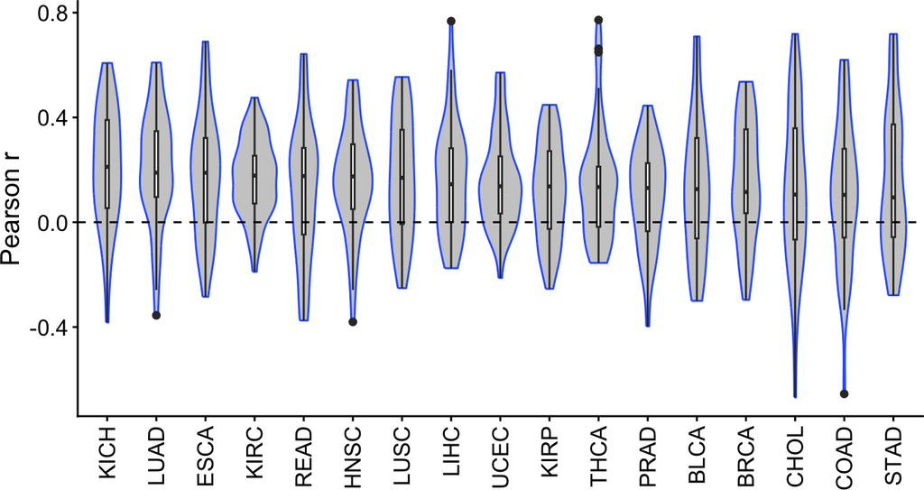

```r
# Remove NAs
miRs_table <- miRs_table[!is.na(miRs_table$correlation), ]

# Sort by the median correlation coefficient in each cancer
medians <- aggregate(miRs_table$correlation, list(miRs_table$cancer), median)
order_cancers <- as.vector(medians[,1][order(medians[,2], decreasing = T)])
miRs_table$cancer <- factor(miRs_table$cancer, levels = order_cancers)
miRs_table <- miRs_table %>% arrange(cancer)

saveRDS(miRs_table, here("TCGA", "output", "rds", "TCGA_miRhostGenes_abundance_vs_activity.rds"))

# Draw the violin plot
p <- ggplot(miRs_table, aes(x = cancer, y = correlation)) +
  geom_violin(fill = "grey80", colour = "#3366FF") +
  geom_boxplot(width = 0.07) +
  theme_classic() +
  ylab("Pearson r") +
  xlab("") +
  theme(axis.text=element_text(size=12),
        axis.title=element_text(size=14),
        axis.text.x = element_text(angle = 90, vjust = 0.5, hjust=1),
        legend.position = "none") +
  geom_hline(yintercept=0, linetype="dashed",
            color = "black", size=0.5)
p
```

```r
pdf(here("TCGA", "output", "figures", "TCGA_miRNA_act_vs_expr_miRfamsSig10T_violin.pdf"), 7, 3.5)
p
dev.off()
```

# 12 Average coefficient of correlationbetween the activity and abundance of matching mature miRNA - miRNA family pairs. Across all tumors of all cancers

```r
mean(miRs_table$correlation)
```

```
## [1] 0.1524822
```

# 13 Heatmap

```r
# Convert miRs_table to wide format with mature miRNAs as rows and cancers as columns
dat_htmp <- miRs_table[,-1] |>
  pivot_wider(names_from = cancer, values_from = correlation, values_fill = 0) |>
  column_to_rownames("mature_miRNA") |>
  as.matrix()
head(dat_htmp)
```

```
##                      KICH      LUAD        ESCA       KIRC        READ
## hsa-let-7a-5p  0.27429509 0.4253899  0.05633529 0.16606945  0.31704107
## hsa-let-7b-5p  0.15592829 0.4130940  0.35105641 0.25726183  0.16671060
## hsa-let-7c-5p -0.04399245 0.3447233  0.37318328 0.11641644  0.19230928
## hsa-let-7d-5p -0.38221597 0.1227383 -0.05496260 0.08056504 -0.37499765
## hsa-let-7e-5p  0.06586346 0.1850798 -0.01074241 0.21364169  0.29955152
## hsa-let-7f-5p  0.21136501 0.3072753 -0.14088374 0.07135249  0.03882691
##                      HNSC        LUSC      LIHC       UCEC        KIRP
## hsa-let-7a-5p  0.26566933  0.21523674 0.2468308 0.34937458  0.07346533
## hsa-let-7b-5p  0.36651674  0.47167871 0.3039756 0.33380589  0.02832776
## hsa-let-7c-5p  0.09408636  0.14079183 0.2610239 0.13742302  0.01740938
## hsa-let-7d-5p -0.07359645  0.09679668 0.1138873 0.04784168 -0.25393593
## hsa-let-7e-5p  0.22695662 -0.02539568 0.2517840 0.02310206  0.14816114
## hsa-let-7f-5p  0.10823837 -0.05577971 0.1634937 0.16922909 -0.07577874
##                      THCA        PRAD        BLCA        BRCA        CHOL
## hsa-let-7a-5p  0.11291315  0.16365336  0.11970393  0.39225746  0.16903421
## hsa-let-7b-5p -0.15490486  0.21464083  0.17353368  0.53616074  0.21095593
## hsa-let-7c-5p -0.06483702  0.13575044  0.23217459  0.05282937  0.01116759
## hsa-let-7d-5p -0.06171487 -0.12128923 -0.22836358 -0.12616960 -0.21808609
## hsa-let-7e-5p  0.17825330  0.02776238 -0.13295204  0.11309177  0.07976461
## hsa-let-7f-5p  0.17672502 -0.03480991 -0.06015821  0.02755448 -0.02487227
##                      COAD         STAD
## hsa-let-7a-5p  0.24490678 -0.015566018
## hsa-let-7b-5p  0.27239836  0.135128417
## hsa-let-7c-5p  0.36603823  0.444002827
## hsa-let-7d-5p -0.22532801 -0.249676649
## hsa-let-7e-5p  0.24118668  0.002785011
## hsa-let-7f-5p -0.01522246 -0.129584037
```

```r
# Draw the heatmap
palette <- colorRampPalette(c("blue", "white", "red"))
pdf(here("TCGA", "output", "figures", "TCGA_miRNA_act_vs_expr_miRfamsSig10T_htmp.pdf"), width=18, height=7)
heatmap.2(dat_htmp, trace="none", col=palette, cexRow=0.01, cexCol=2,  breaks=seq(-1,1,length.out=50), mar=c(10,10), keysize=1, hclust=function(x) hclust(x,method="complete"), distfun = function(x) dist(x,method = 'euclidean'), density.info = "none", key.par = list(cex=2), lhei=c(1,1.2), lwid = c(1,2), Colv = F, key.title = "", key.xlab = "Pearson r")
dev.off()
```

# 14 Helper function to create scatter plots

```r
plot_mir_abundance_vs_activity <- function(cancer, miRNA_fam, miRNA_mature, glm_results, save_pdf = NULL) {
  # Load abundance
  miR_expr_T <- load_mir_abundance(cancer)

  # Extract activity (long format)
  miR_act_long <- extract_mir_activity(cancer, glm_results, miRNA_fam)

  # Match samples
  common_samples <- intersect(unique(miR_act_long$sample_name), colnames(miR_expr_T))
  miR_expr_T <- miR_expr_T[, common_samples]
  miR_act_long <- miR_act_long |> filter(sample_name %in% common_samples)

  # Check if miRNA family exists
  if (nrow(miR_act_long) == 0) {
    cat("Warning: miRNA family", miRNA_fam, "not found in activity data\n")
    return(invisible())
  }

  # Sort by sample name for correct alignment
  miR_act_long <- miR_act_long |> arrange(factor(sample_name, levels = common_samples))
  expr_samples <- common_samples
  expr_vals <- as.numeric(miR_expr_T[miRNA_mature, common_samples])
  act_samples <- miR_act_long$sample_name
  act_vals <- miR_act_long$coefficient_log2

  # Verify sample names match in the same order
  stopifnot(
    "Expression and activity samples must match in the same order" =
      all(expr_samples == act_samples)
  )

  # Save to PDF
  if (!is.null(save_pdf)) {
    pdf(save_pdf, width = 3.5, height = 4.2)
  }

  # Create plot
  plot(expr_vals, act_vals, pch = 16, cex = 0.5,
       xlab = paste0(miRNA_fam, " expression log2(RPM)"), ylab = paste0(miRNA_fam, " activity"),
       cex.axis = 0.8, cex.lab = 1.2)
  abline(lm(act_vals ~ expr_vals), col = 4, lwd = 2)

  # Add correlation and p-value
  test_res <- cor.test(expr_vals, act_vals)
  r <- test_res$estimate
  p <- test_res$p.value
  n <- length(expr_vals)
  text(min(expr_vals, na.rm = TRUE), max(act_vals, na.rm = TRUE),
       paste0("r = ", round(r, 3), "\np = ", formatC(p, format = "e", digits = 3), "\nn = ", n),
       adj = c(0, 1), cex = 0.9)

  # Close PDF if it was opened
  if (!is.null(save_pdf)) {
    dev.off()
  }

  invisible(NULL)
}
```

# 15 Example scatter plot for hsa-miR-122-5p in LIHC

```r
plot_mir_abundance_vs_activity("LIHC", "miR-122-5p", "hsa-miR-122-5p", glm_results, save_pdf = here("TCGA", "output", "figures", "TCGA_miRNA_act_vs_expr_miR122_LIHC.pdf"))
```

# 16 Example scatter plot for miR-143-3p in HNSC

```r
plot_mir_abundance_vs_activity("HNSC", "miR-143-3p", "hsa-miR-143-3p", glm_results, save_pdf = here("TCGA", "output", "figures", "TCGA_miRNA_act_vs_expr_miR143_HNSC.pdf"))
```

# 17 Show, as examples, the individual coefficients for the correlations between inferred activity of each miRNA family included above with the abundance of each of their family members, in TCGA-KIRC and TCGA-LUAD

```r
# Helper function to create a color palette for all miR families
create_global_mir_family_colors <- function(miRs_table) {

  # Get all unique miR families across all cancers
  all_families <- sort(unique(miRs_table$miR_family))

  # Generate enough distinct colors
  cols <- glasbey.colors(length(all_families))

  # Replace the lightest/white color
  lightest <- which.max(
    sapply(cols, function(x) {
      rgb <- col2rgb(x)
      mean(rgb)
    })
  )

  cols[lightest] <- "#7B3294"

  # Shuffle the colors with a fixed seed for reproducibility
  set.seed(1)
  cols <- sample(cols)

  # Assign colors to families
  names(cols) <- all_families

  cols
}

# Helper function to plot miRNA family correlations for a specific cancer
plot_mir_family_correlations <- function(cancer, miRs_table, color_palette, save_pdf = NULL) {

  # Validate that the cancer is in the data
  if (!(cancer %in% unique(miRs_table$cancer))) {
    stop("Cancer type '", cancer, "' not found in data. Available cancers: ",
         paste(sort(unique(miRs_table$cancer)), collapse = ", "))
  }

  # Data for this cancer
  miRs_table_cancer <- miRs_table[miRs_table$cancer == cancer, ]

  # Get families present in this cancer (to ensure color palette includes all)
  families_in_cancer <- unique(miRs_table_cancer$miR_family)

  # Verify all families are in the color palette
  missing_families <- setdiff(families_in_cancer, names(color_palette))
  if (length(missing_families) > 0) {
    stop("The following families in cancer '", cancer, "' are not in the color palette: ",
         paste(missing_families, collapse = ", "))
  }

  # Use only the colors for families present in this cancer
  cols_for_cancer <- color_palette[families_in_cancer]

  # Create the plot
  p <- ggplot(miRs_table_cancer,
              aes(x = mature_miRNA,
                  y = correlation,
                  fill = miR_family)) +
    geom_col() +
    scale_fill_manual(values = cols_for_cancer) +
    theme_classic() +
    labs(
      x = "Mature miRNA",
      y = "Pearson r",
      fill = "miRNA family",
      title = cancer
    ) +
    theme(
      axis.text.x = element_text(
        angle = 90,
        hjust = 1,
        vjust = 0.5,
        size = 10
      ),
      axis.text.y = element_text(size = 10),
      axis.title = element_text(size = 12),
      plot.title = element_text(size = 14, face = "bold", hjust = 0.5),
      legend.position = "bottom",
      legend.key.size = unit(c(0.4, 0.4), "cm"),
      legend.text = element_text(size = 8)
    )

  # Save to PDF if requested
  if (!is.null(save_pdf)) {
    pdf(save_pdf, width = 7, height = 5)
    print(p)
    dev.off()
    cat("Plot saved to:", save_pdf, "\n")
  }

  # Return the plot object invisibly
  invisible(p)
}

# Create global color palette (consistent across all cancers)
global_mir_colors <- create_global_mir_family_colors(miRs_table)
```

```r
# Plot for KIRC
p_kirc <- plot_mir_family_correlations(
  cancer = "KIRC",
  miRs_table = miRs_table,
  color_palette = global_mir_colors,
  save_pdf = here("TCGA", "output", "figures", "TCGA_miRNA_act_vs_expr_miRfamsSig10T_KIRC_barplot.pdf")
)
```

```
## Plot saved to: /Users/gabrielleperron/Documents/RBP-miRNA-manuscript/TCGA/output/figures/TCGA_miRNA_act_vs_expr_miRfamsSig10T_KIRC_barplot.pdf
```

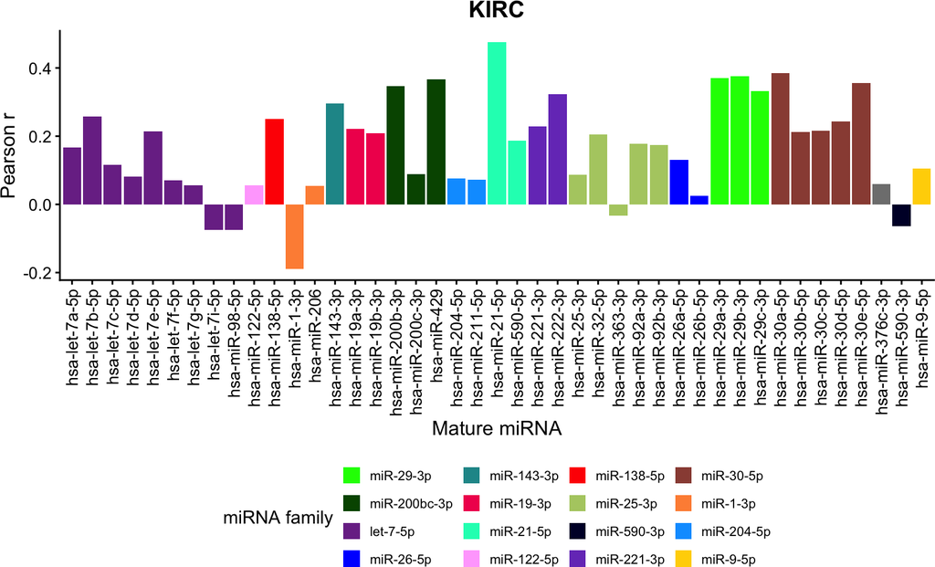

```r
p_kirc
```

```r
# Plot for LUAD
p_luad <- plot_mir_family_correlations(
  cancer = "LUAD",
  miRs_table = miRs_table,
  color_palette = global_mir_colors,
  save_pdf = here("TCGA", "output", "figures", "TCGA_miRNA_act_vs_expr_miRfamsSig10T_LUAD_barplot.pdf")
)
```

```
## Plot saved to: /Users/gabrielleperron/Documents/RBP-miRNA-manuscript/TCGA/output/figures/TCGA_miRNA_act_vs_expr_miRfamsSig10T_LUAD_barplot.pdf
```

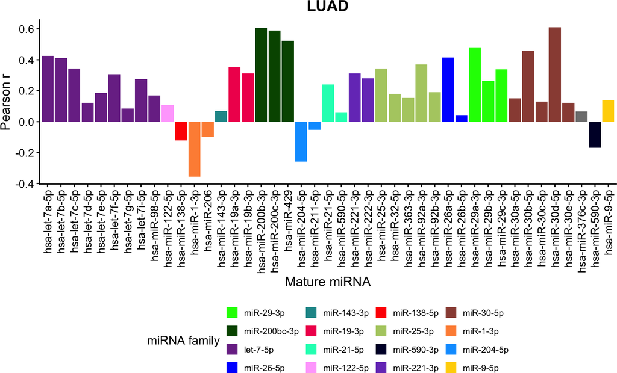

```r
p_luad
```